# Aufgabe 3: Zusammenhangshypothese -Gruppe C

## Aufgabenstellung

1. Hypothese
2. Voraussetzungen
3. Grundlegende Konzepte: Was ist Pearson?
4. Grafische Veranschaulichung des Zusammenhangs
5. Deskriptive Statistik
6. Ergebnisse der Korrelationsanalyse
7. Berechnung des Bestimmtheitsmasses
8. Berechnung der Effektstärke
9. Eine Aussage

Ziel der Studie ist es herauszufinden, ob eine Zusammenhang zwischen dem Gewicht und Blutdruck der Patient_innen besteht. Dafür wird der Pearson angewendet.

Datensatz: cleanhospital.xlsx  
Variable1: Körpergewicht  
Varibale2: Blutdruck

```r
df_pearson <- cleanhospital <- read_excel("cleanhospital.xlsx")
View(cleanhospital)
```

```r
library(psych)
library(car)
library(dplyr)
library(ggplot2)
```

# ——————————————————————————

#### Umgang mit fehlenden Werten

```r
sum(is.na(df_pearson))
```

```
[1] 4
```

```r
df_pearson1 <- na.omit(df_pearson)
```

```r
summary(df_pearson1$weight)
```

```
   Min. 1st Qu.  Median    Mean 3rd Qu.    Max.
  38.60   65.90   77.55   80.82   90.38  162.00
```

```r
summary(df_pearson1$systolic_blood_pressure)
```

```
   Min. 1st Qu.  Median    Mean 3rd Qu.    Max.
   85.0   115.0   127.0   131.1   146.0   227.0
```

```r
sum(is.na(df_pearson1$weight))
```

```
[1] 0
```

# ——————————————————————————

# 1) Hypothese

H0 : Es gibt keinen Zusammenhang zwischen dem Körpergewicht und Blutdruck der Patient_innen.

H1 : Es gibt einen Zusammenhang zwischen dem Körpergewicht und Blutdruck der Patient

# ——————————————————————————

# 2) Voraussetzungen

## Histogram fuer die Normalverteilung

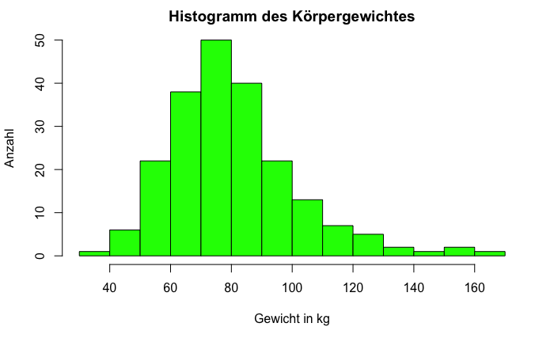

```r
hist(df_pearson1$weight, main = "Histogramm des Körpergewichtes", xlab = "Gewicht in kg", ylab = "Anzahl", col = "green" )
```

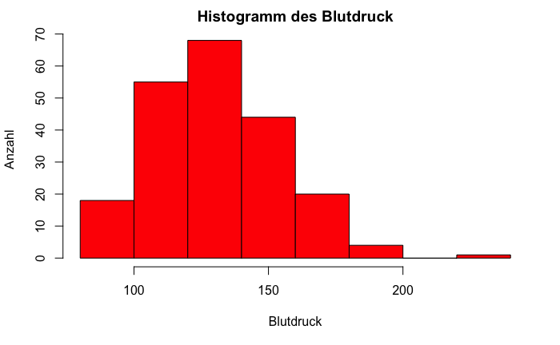

```r
hist(df_pearson1$systolic_blood_pressure, main = "Histogramm des Blutdruck", xlab = "Blutdruck", ylab = "Anzahl", col = "red" )
```

# ——————————————————————————

# 3) Grundlegende Konzepte: Was ist Pearson?

Die Korrelation beschreibt den Zusammenhang von zwei intervallskalierten Merkmalen/Variablen einer Zufallsstichprobe. Die Stärke des Zusammenhangs lässt sich mit Hilfe des Korrelationskoeffizienten r nach Bravais und Pearson berechnen. Die Variablen sind unabhängig voneinander und folglich werden keine kausalen Aussagen gemacht.

# ——————————————————————————

# 4) Grafische Veranschaulichung des Zusammenhangs

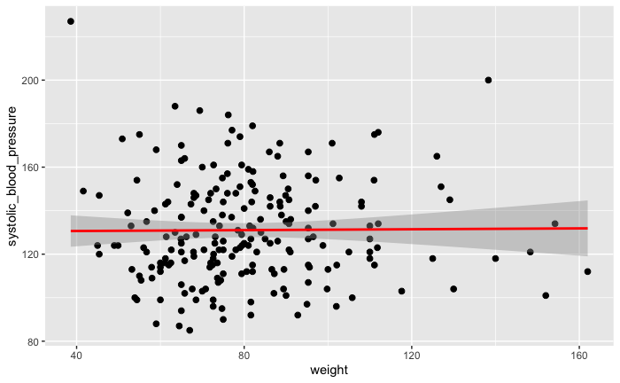

```r
library(ggplot2)
ggplot(df_pearson1, aes(x = weight, y = systolic_blood_pressure))+
geom_point(size = 2)+
geom_smooth(method = "lm",col = "red")
```

Dass Streudigramm zeigt, dass es keinen linear-positiven Zusammenhang zwischen den Variablen Gewicht und Blutdruck gibt.